# Rishika Projectf Vehicle Insurace

## Unlocking Insights: Exploratory Data Analysis of Vehicle Insurance Trends

[figure not shown]

## Problem Statement:

The increasing complexity of vehicle insurance management, including identifying risk factors, understanding customer demographics, and optimizing policyholder retention, poses challenges for insurance providers. Effective data analysis is critical to uncover patterns and insights that can drive strategic decisions, such as tailoring policies and improving customer satisfaction.

## Goal:

To conduct an exploratory data analysis (EDA) on the vehicle insurance dataset to identify key trends, relationships, and insights that can assist in understanding policyholder behavior, risk profiling, and optimizing insurance offerings.

# Dataset Description

**Key Variables**

### Import Libraries

```python
import pandas as pd
import numpy as np
import matplotlib.pyplot as plt
import seaborn as sns
```

### Step 1: Data Loading and Inspection

```python
def basic_analysis(df):
    # Display the first five rows
    print("Head of the DataFrame:")
    print(df.head())
    print("\n" + "="*50 + "\n")

    # Display the last five rows
    print("Tail of the DataFrame:")
    print(df.tail())
    print("\n" + "="*50 + "\n")

    # Display the size of the DataFrame
    print("Size of the DataFrame:")
    print(df.size)
    print("\n" + "="*50 + "\n")

    # Display the shape of the DataFrame
    print("Shape of the DataFrame:")
    print(df.shape)
    print("\n" + "="*50 + "\n")

    # Display basic info about the DataFrame
    print("Info of the DataFrame:")
    print(df.info())
    print("\n" + "="*50 + "\n")

    # Display descriptive statistics
    print("Descriptive Statistics of the DataFrame:")
    print(df.describe())
    print("\n" + "="*50 + "\n")

df=pd.read_csv("C:/Users/DELL-/Downloads/Vehicle_Insurance.csv")
basic_analysis(df)
df2=pd.DataFrame(df)
```

```
Head of the DataFrame:
   id  Gender  Age  Driving_License  Region_Code  Previously_Insured  \
0   1    Male   44                1         28.0                   0
1   2    Male   76                1          3.0                   0
2   3    Male   47                1         28.0                   0
3   4    Male   21                1         11.0                   1
4   5  Female   29                1         41.0                   1

  Vehicle_Age Vehicle_Damage  Annual_Premium  Policy_Sales_Channel  Vintage  \
0   > 2 Years            Yes         40454.0                  26.0      217
1    1-2 Year             No         33536.0                  26.0      183
2   > 2 Years            Yes         38294.0                  26.0       27
3    < 1 Year             No         28619.0                 152.0      203
4    < 1 Year             No         27496.0                 152.0       39

   Response
0         1
1         0
2         1
3         0
4         0

==================================================

Tail of the DataFrame:
            id  Gender  Age  Driving_License  Region_Code  Previously_Insured  \
381104  381105    Male   74                1         26.0                   1
381105  381106    Male   30                1         37.0                   1
381106  381107    Male   21                1         30.0                   1
381107  381108  Female   68                1         14.0                   0
381108  381109    Male   46                1         29.0                   0

       Vehicle_Age Vehicle_Damage  Annual_Premium  Policy_Sales_Channel  \
381104    1-2 Year             No         30170.0                  26.0
381105    < 1 Year             No         40016.0                 152.0
381106    < 1 Year             No         35118.0                 160.0
381107   > 2 Years            Yes         44617.0                 124.0
381108    1-2 Year             No         41777.0                  26.0

        Vintage  Response
```

[output cut: 59 more lines]

```
50%              0.000000    31669.000000            133.000000
75%              1.000000    39400.000000            152.000000
max              1.000000   540165.000000            163.000000

             Vintage       Response
count  381109.000000  381109.000000
mean      154.347397       0.122563
std        83.671304       0.327936
min        10.000000       0.000000
25%        82.000000       0.000000
50%       154.000000       0.000000
75%       227.000000       0.000000
max       299.000000       1.000000

==================================================
```

### STEP2: Data Cleaning:

#### Handling missing values

```python
print("Identify Null values")
print(df.isnull().sum())
```

```
Identify Null values
id                      0
Gender                  0
Age                     0
Driving_License         0
Region_Code             0
Previously_Insured      0
Vehicle_Age             0
Vehicle_Damage          0
Annual_Premium          0
Policy_Sales_Channel    0
Vintage                 0
Response                0
dtype: int64
```

```python
print("Identify blank values")
# Count blank per column
blank_or_zero_counts = ((df == "") | (df == " " )).sum()
print(blank_or_zero_counts)
```

```
Identify blank values
id                      0
Gender                  0
Age                     0
Driving_License         0
Region_Code             0
Previously_Insured      0
Vehicle_Age             0
Vehicle_Damage          0
Annual_Premium          0
Policy_Sales_Channel    0
Vintage                 0
Response                0
dtype: int64
```

### Findings and Insights

- The dataset is complete with no missing or null values. This is a strong foundation for analysis as it reduces the need for data cleaning related to missing values, ensuring that insights are based on a fully intact dataset.

### Handling outliers

- Visualised Outliers in dataset

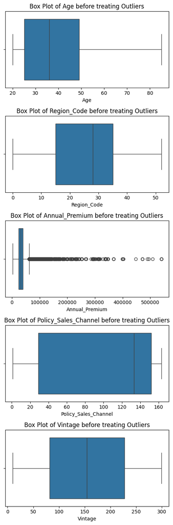

```python
# List of specific columns to plot
columns_to_plot = ['Age', 'Region_Code', 'Annual_Premium','Policy_Sales_Channel','Vintage']

# Plot box plots for the selected columns
plt.figure(figsize=(5, len(columns_to_plot) * 3))  # Adjust figure size
for i, column in enumerate(columns_to_plot):
    plt.subplot(len(columns_to_plot), 1, i + 1)
    sns.boxplot(x=df[column])
    plt.title(f'Box Plot of {column} before treating Outliers')
    plt.tight_layout()
plt.show()
```

### Findings and Insights

- The Annual Premium column in the dataset contains numerous outliers. These outliers can skew the results and lead to inaccurate predictions in any models built using this data. Therefore, it is essential to address and treat these outliers to ensure the integrity and reliability of any subsequent analysis.
- On the other hand, the remaining columns exhibit minimal or no outliers and can be considered stable. Consequently, the primary focus should be on handling the outliers in the Annual Premium column.

### Replacing outliers by lower bound and by upper bound

```python
def replace_outliers(data, column):
    Q1 = data[column].quantile(0.25)
    Q3 = data[column].quantile(0.75)

    IQR = Q3 - Q1

    lower_bound = Q1 - 1.5 * IQR
    upper_bound = Q3 + 1.5 * IQR

    # Replace values below lower bound with lower bound and values above upper bound with upper bound
    data[column] = data[column].apply(lambda x: lower_bound if x < lower_bound else (upper_bound if x > upper_bound else x))

    return data

data = replace_outliers(df2, 'Annual_Premium')
```

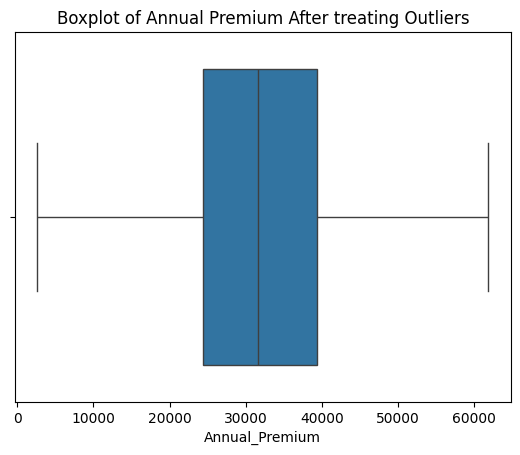

```python
sns.boxplot(x=df2['Annual_Premium'])
plt.title("Boxplot of Annual Premium After treating Outliers")
plt.show()
```

### STEP3: Data Visualization:

#### Histograms for Numeric Values

- In this dataset, there are Numeric Values like Age, Annual_Premium, Vintage.

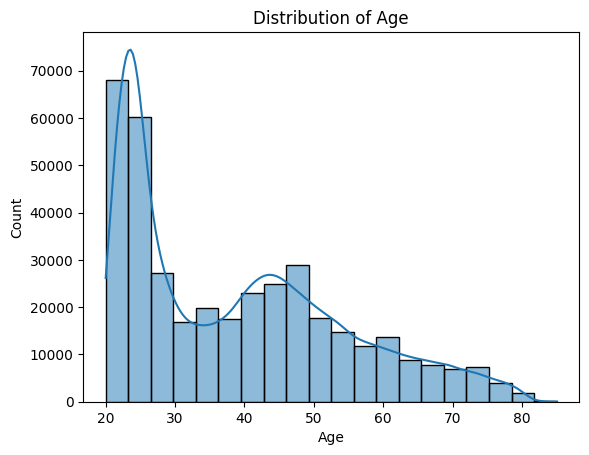

```python
sns.histplot(df2['Age'],bins=20,kde=True)
plt.title('Distribution of Age')
plt.show()
```

## Distribution of Age :

#### Recommendations

- Targeted Strategies for Age Group 40 and Above: Create insurance products tailored to the needs and financial capacities of individuals over 40. Offer incentives or discounts to boost insurance adoption in this age group.
- Engagement with Younger Age Groups: Continue to provide customized insurance plans for the 20-25 age group. Highlight the advantages of early insurance coverage to build lasting customer relationships.

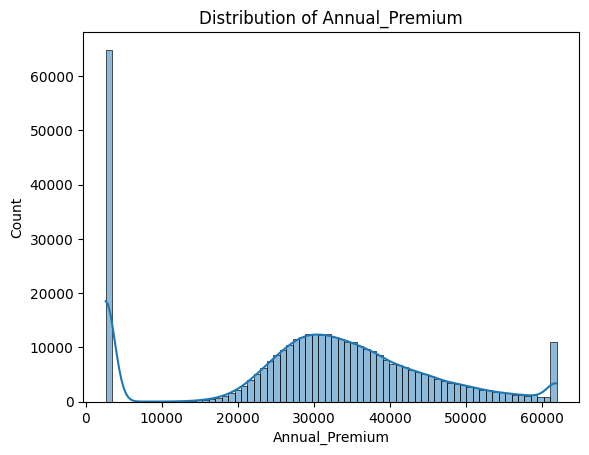

```python
sns.histplot(df2['Annual_Premium'],bins=70,kde=True)
plt.title('Distribution of Annual_Premium')
plt.show()
```

### Distribution of Annual_Premium

#### Recommendations

- Develop Customized Insurance Plans: Tailor insurance products to meet the specific needs of low, medium, and high premium groups.
- Implement Targeted Marketing Campaigns: Create campaigns focused on different premium segments to engage each group effectively.

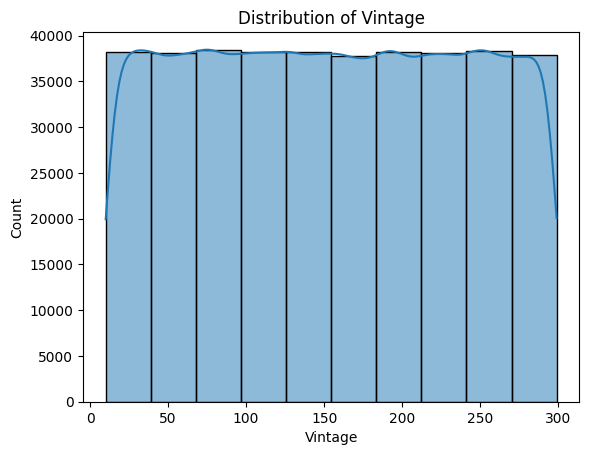

```python
sns.histplot(df2['Vintage'],bins=10,kde=True)
plt.title('Distribution of Vintage')
plt.show()
```

### Distribution of Vintage:

#### Recommendations

- Leverage AI for Decision Making: Use advanced analytics and machine learning to gain deeper insights into customer behavior and refine marketing and product development strategies.
- Boost Digital Presence: Enhance digital presence through social media, online marketing, and user-friendly web platforms to attract more customers and improve access to services

### Pie Plot for Categorical Variables

#### Distribution of Gender

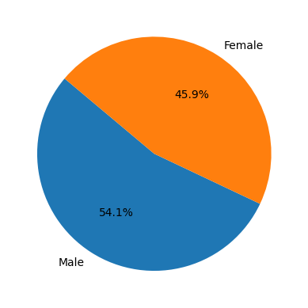

```python
labels= ['Male','Female']
plt.pie(df2['Gender'].value_counts(), autopct='%1.1f%%', labels=labels,startangle=140)
plt.show()
```

#### Insights

##### Gender:

- **Male Majority**: The dataset shows a higher number of males, with a Percentage of **54.1%**.
- **Female Count**: The number of females is close to the number of males, with a Percentage of **45.9%**.

#### Distribution of Vehicle_Age

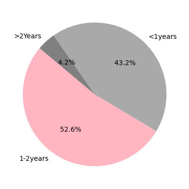

```python
labels= ['1-2years','<1years','>2Years']
colors=['lightpink','darkgrey','grey']
plt.pie(df2['Vehicle_Age'].value_counts(), autopct=' %1.1f%%',colors=colors, labels=labels,startangle=140)
plt.show()
```

### Insights

#### Distribution of Vehicle_Damage

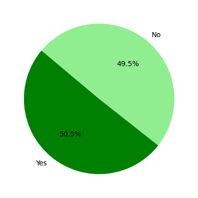

```python
labels= ['Yes','No']
colors=['green','lightgreen']
plt.pie(df2['Vehicle_Damage'].value_counts(), autopct='%1.1f%%',colors=colors, labels=labels,startangle=140)
plt.show()
```

### Insights

#### Vehicle_Damage:

- **Vehicle Damage - Yes:** The percentage of vehicles with damage reported as "Yes" is **50.5%**, indicating a significant number of vehicles that have sustained damage.
- **Vehicle Damage - No:** The percentage of vehicles with damage reported as "No" is **49.5%**, indicating a substantial number of vehicles that have not sustained any damage.

#### Distribution of Previously_Insured

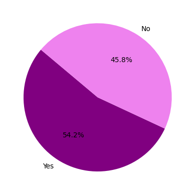

```python
labels= ['Yes','No']
colors=['purple','violet']
plt.pie(df2['Previously_Insured'].value_counts(), autopct='%1.1f%%',colors=colors, labels=labels,startangle=140)
plt.show()
```

### Insights

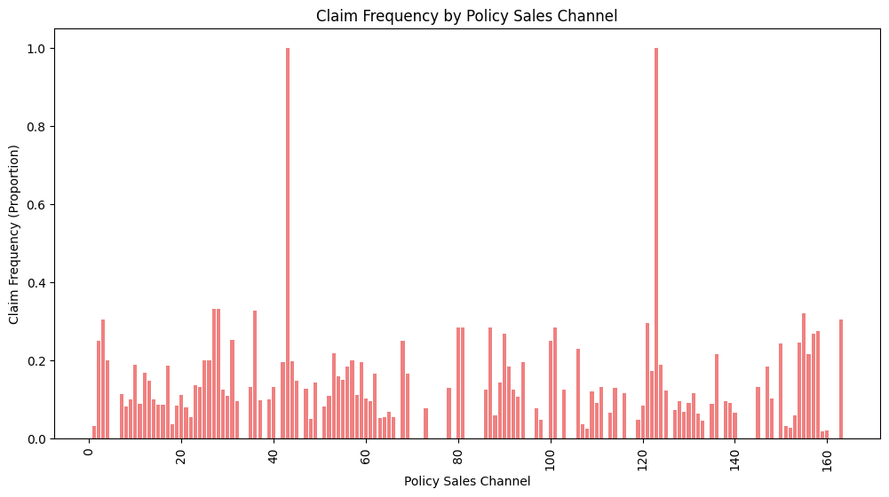

```python
sales_channel_frequency = df2.groupby('Policy_Sales_Channel')['Response'].mean()
plt.figure(figsize=(12, 6))
plt.bar(sales_channel_frequency.index, sales_channel_frequency.values, color="lightcoral")
plt.title('Claim Frequency by Policy Sales Channel')
plt.xlabel('Policy Sales Channel')
plt.ylabel('Claim Frequency (Proportion)')
plt.xticks(rotation=90)
plt.show()
```

### Insights

##### Policy Analysis:

- Most policy sales channels have relatively low claim frequencies, generally below 0.2.
- A few specific sales channels (notably around 40 and 120) exhibit extremely high claim frequencies, reaching 1.0, indicating that all policies sold through these channels resulted in claims.
- There is significant variability in claim frequencies across the sales channels, with some clusters showing moderate frequencies and others near-zero.
- This suggests that certain sales channels are highly associated with claims, likely requiring further investigation into their policyholder demographics or practices.

## Recommendations

- Customer Engagement & Segmentation: Target male customers with specific marketing campaigns and design tailored offers for different vehicle age groups to enhance engagement and retention.
- Address Vehicle Damage & Uninsured Trends: Develop specialized insurance plans for vehicles with damage, preventive maintenance programs for those without, and attract previously uninsured individuals with introductory offers.
- Personalization & Technology Enhancement: Use data analytics and AI for personalized interactions, decision-making, and strengthen digital presence to improve customer support and access to services.

### STEP4: Feature Analysis

#### Analyse the relation between Target and Feature variable

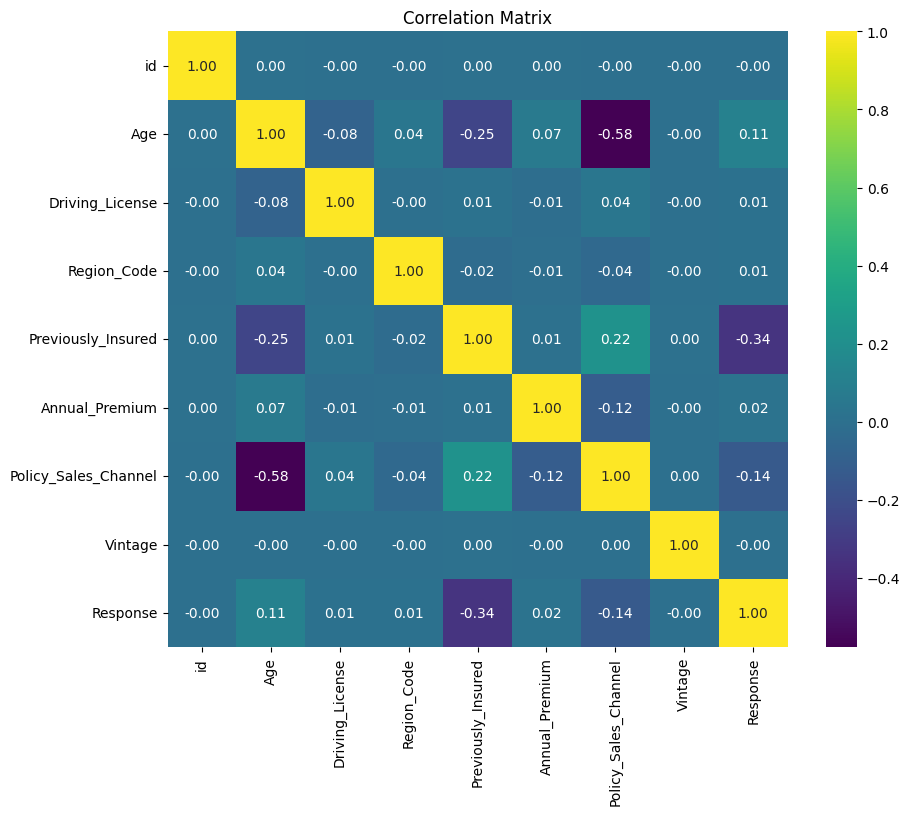

```python
numerical_df=df2.select_dtypes(include='number')
correlation_matrix = numerical_df.corr()
plt.figure(figsize=(10,8))
sns.heatmap(correlation_matrix, annot=True, cmap='viridis', fmt=".2f")
plt.title('Correlation Matrix')
plt.show()
```

### KEY FINDINGS AND RECOMMENDATIONS

#### Insights

- **Previously_Insured negatively impacts Response (-0.341)** —non-insured customers are more likely to respond.
- **Policy_Sales_Channel and Age have a moderate negative correlation (-0.578)** —older customers might prefer specific channels less.
- **Most features show weak or negligible correlation with Response.**

#### Recommendations

- **Focus on Non-Insured Customers:** Target individuals without prior insurance, as they are more likely to convert. Adjust marketing efforts accordingly.
- **Optimize Sales Channels for Older Customers:** Revise strategies for older customer groups, potentially leveraging channels better suited to their preferences.

### STEP5: Age Distribution Analysis

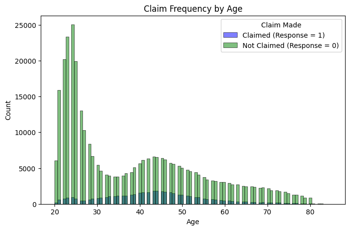

```python
plt.figure(figsize=(8, 5))
colors=['green', 'blue']
sns.histplot(x='Age', hue='Response', data=df2, palette=colors)
plt.title('Claim Frequency by Age')
plt.xlabel('Age')
plt.ylabel('Count')
plt.legend(title='Claim Made', labels=['Claimed (Response = 1)', 'Not Claimed (Response = 0)'])
plt.show()
```

### Recommendations

- Retention: Focus on retaining younger customers with custom offers.
- Claims Strategy: Offer tailored packages for older, higher-claim customers.
- Gender Targeting: Develop targeted marketing for female customers to balance the portfolio.

### STEP6: Premium Analysis

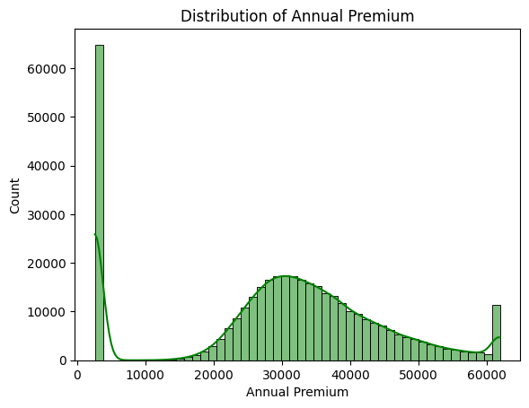

```python
sns.histplot(df2['Annual_Premium'], bins=50, kde=True,color='green')
plt.title('Distribution of Annual Premium')
plt.xlabel('Annual Premium')
plt.show()
```

##### Correlation between Annual Premium and Response

```python
correlation = df2['Annual_Premium'].corr(df2['Response'])
print(f"Correlation between Annual Premium and Response: {correlation:.3f}")
```

```
Correlation between Annual Premium and Response: 0.022
```

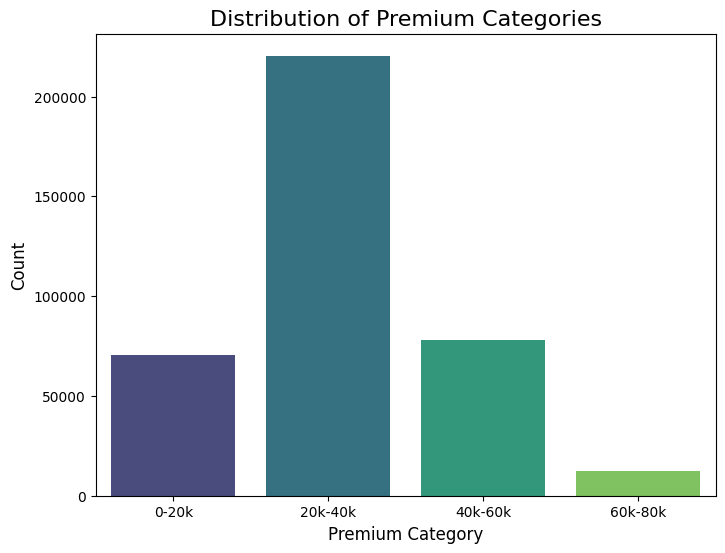

```python
# Categorize premiums into bins
bins = [0, 20000, 40000, 60000, 80000]
labels = ['0-20k', '20k-40k', '40k-60k', '60k-80k']
df2['Premium_Category'] = pd.cut(df2['Annual_Premium'], bins=bins, labels=labels)

# Count plot for premium categories
plt.figure(figsize=(8, 6))
sns.countplot(data=df2, x='Premium_Category', palette='viridis')
plt.title('Distribution of Premium Categories', fontsize=16)
plt.xlabel('Premium Category', fontsize=12)
plt.ylabel('Count', fontsize=12)
plt.show()
```

### KEY FINDINGS AND RECOMMENDATIONS

#### Recommendations

- Revise Pricing Strategy: Introduce mid-tier policy options to address the skewed distribution.
- Segment High-Premium Customers: Analyze the 60,000-premium group to understand and target this segment.

### STEP7: Claim Frequency Analysis

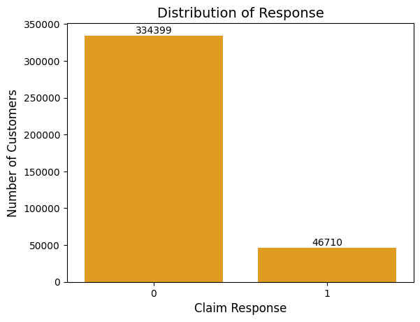

```python
ax=sns.countplot(data=df2,x='Response',color='orange')
for bars in ax.containers:
    ax.bar_label(bars)
# Customize the plot
plt.title('Distribution of Response', fontsize=14)
plt.xlabel('Claim Response', fontsize=12)
plt.ylabel('Number of Customers', fontsize=12)
plt.show()
```

##### Bar plot for Gender vs Response

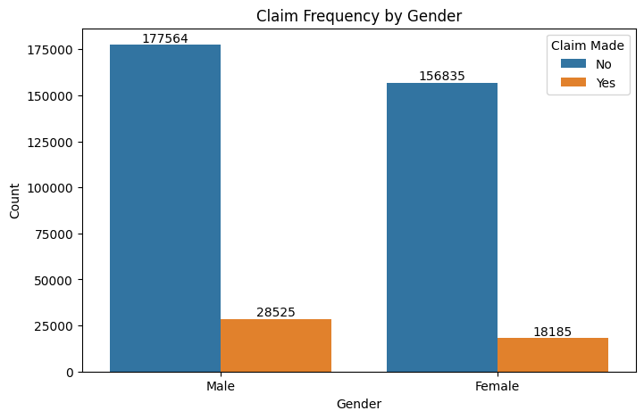

```python
plt.figure(figsize=(8, 5))
ax=sns.countplot(x='Gender', hue='Response', data=df2)
for bars in ax.containers:
    ax.bar_label(bars)
plt.title('Claim Frequency by Gender')
plt.xlabel('Gender')
plt.ylabel('Count')
plt.legend(title='Claim Made', labels=['No', 'Yes'])
plt.show()
```

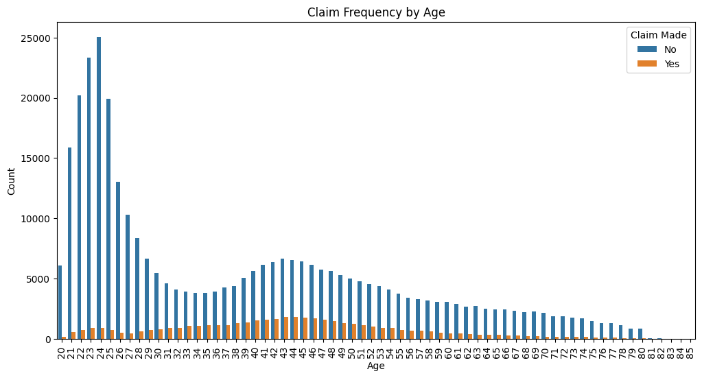

```python
plt.figure(figsize=(12, 6))
sns.countplot(x='Age', hue='Response', data=df2)
plt.title('Claim Frequency by Age')
plt.xlabel('Age')
plt.xticks(rotation=90)
plt.ylabel('Count')
plt.legend(title='Claim Made', labels=['No', 'Yes'])
plt.show()
```

### Insights:

#### Claim Response:

- Majority (334,399) did not make a claim; only 46,710 made a claim.

#### By Gender:

- Claims are similar across genders, with slightly more "No Claim" responses from males.

### STEP8: Gender Analysis

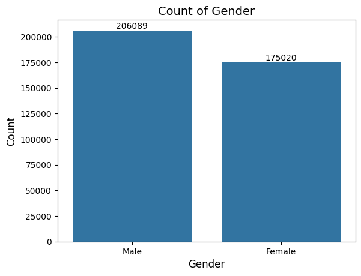

```python
ax=sns.countplot(data=df2,x='Gender')
for bars in ax.containers:
    ax.bar_label(bars)

# Customize the plot
plt.title('Count of Gender', fontsize=14)
plt.xlabel('Gender', fontsize=12)
plt.ylabel('Count', fontsize=12)
plt.show()
```

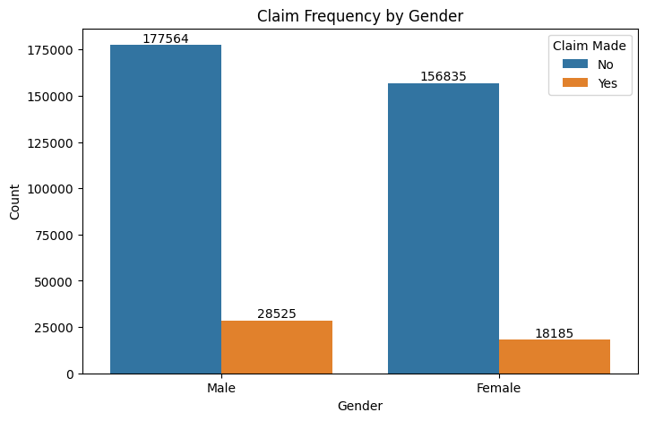

```python
plt.figure(figsize=(8, 5))
ax=sns.countplot(x='Gender', hue='Response', data=df2)
for bars in ax.containers:
    ax.bar_label(bars)
plt.title('Claim Frequency by Gender')
plt.xlabel('Gender')
plt.ylabel('Count')
plt.legend(title='Claim Made', labels=['No', 'Yes'])
plt.show()
```

### Insights:

#### Male Dominance:

- Males (54%) outnumber females (46%) in the dataset.

#### Claim Behavior:

- Both genders show similar claim trends, with most not making claims.

#### Proportionate Claims:

- Slightly more male claims align with their higher population.

### Recommendations:

- Focus on gender-neutral policies due to similar claim behavior.
- Adjust marketing and risk strategies to match gender proportions.
- Investigate claim ratios for potential underwriting refinements.

### STEP9: Vehicle Age and Claims Analysis

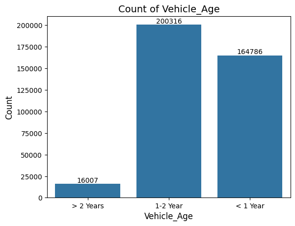

```python
ax=sns.countplot(data=df2,x='Vehicle_Age')
for bars in ax.containers:
    ax.bar_label(bars)
# Customize the plot
plt.title('Count of Vehicle_Age', fontsize=14)
plt.xlabel('Vehicle_Age', fontsize=12)
plt.ylabel('Count', fontsize=12)
plt.show()
```

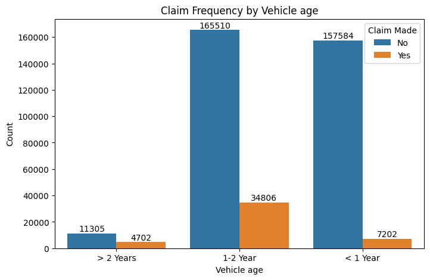

```python
plt.figure(figsize=(8, 5))
ax=sns.countplot(x='Vehicle_Age', hue='Response', data=df2)
for bars in ax.containers:
    ax.bar_label(bars)
plt.title('Claim Frequency by Vehicle age')
plt.xlabel('Vehicle age')
plt.ylabel('Count')
plt.legend(title='Claim Made', labels=['No', 'Yes'])
plt.show()
```

### Insights:

#### Vehicle Age Distribution:

- 1-2 years: Largest group (200,316 entries).
- <1 year: Second largest (164,786 entries).
- (>2) years: Smallest group (16,007 entries).

### Recommenndations

- Run safe-driving awareness campaigns.
- Offer insurance plans that reward safe driving.
- Provide affordable, basic coverage options.
- Offer discounts or rewards for no-claim customers.
- Check if factors like vehicle type or location affect claims.